# Risk Factor Analysis

## Outcome Variable

**Outcome Variable:** ever_swasted

## Predictor Variables

**Intervention Variable:** enstunt

**Adjustment Set:**

- arm
- sex
- W_mage
- meducyrs
- feducyrs
- vagbrth
- brthmon
- W_parity
- delta_W_mage
- delta_meducyrs
- delta_feducyrs
- delta_vagbrth
- delta_brthmon
- delta_W_parity

## Stratifying Variables

The analysis was stratified on these variable(s):

- agecat
- studyid
- country

## Data Summary

| agecat | studyid | country | enstunt | ever_swasted | n_cell | n |
| --- | --- | --- | --- | --- | --- | --- |
| 0-24 months (no birth wast) | ki0047075b-MAL-ED | BANGLADESH | 0 | 0 | 207 | 263 |
| 0-24 months (no birth wast) | ki0047075b-MAL-ED | BANGLADESH | 0 | 1 | 10 | 263 |
| 0-24 months (no birth wast) | ki0047075b-MAL-ED | BANGLADESH | 1 | 0 | 44 | 263 |
| 0-24 months (no birth wast) | ki0047075b-MAL-ED | BANGLADESH | 1 | 1 | 2 | 263 |
| 0-24 months (no birth wast) | ki0047075b-MAL-ED | BRAZIL | 0 | 0 | 204 | 232 |
| 0-24 months (no birth wast) | ki0047075b-MAL-ED | BRAZIL | 0 | 1 | 3 | 232 |
| 0-24 months (no birth wast) | ki0047075b-MAL-ED | BRAZIL | 1 | 0 | 25 | 232 |
| 0-24 months (no birth wast) | ki0047075b-MAL-ED | BRAZIL | 1 | 1 | 0 | 232 |
| 0-24 months (no birth wast) | ki0047075b-MAL-ED | INDIA | 0 | 0 | 198 | 246 |
| 0-24 months (no birth wast) | ki0047075b-MAL-ED | INDIA | 0 | 1 | 7 | 246 |
| 0-24 months (no birth wast) | ki0047075b-MAL-ED | INDIA | 1 | 0 | 38 | 246 |
| 0-24 months (no birth wast) | ki0047075b-MAL-ED | INDIA | 1 | 1 | 3 | 246 |
| 0-24 months (no birth wast) | ki0047075b-MAL-ED | NEPAL | 0 | 0 | 210 | 239 |
| 0-24 months (no birth wast) | ki0047075b-MAL-ED | NEPAL | 0 | 1 | 1 | 239 |
| 0-24 months (no birth wast) | ki0047075b-MAL-ED | NEPAL | 1 | 0 | 26 | 239 |
| 0-24 months (no birth wast) | ki0047075b-MAL-ED | NEPAL | 1 | 1 | 2 | 239 |
| 0-24 months (no birth wast) | ki0047075b-MAL-ED | PERU | 0 | 0 | 263 | 302 |
| 0-24 months (no birth wast) | ki0047075b-MAL-ED | PERU | 0 | 1 | 3 | 302 |
| 0-24 months (no birth wast) | ki0047075b-MAL-ED | PERU | 1 | 0 | 36 | 302 |
| 0-24 months (no birth wast) | ki0047075b-MAL-ED | PERU | 1 | 1 | 0 | 302 |
| 0-24 months (no birth wast) | ki0047075b-MAL-ED | SOUTH AFRICA | 0 | 0 | 266 | 308 |
| 0-24 months (no birth wast) | ki0047075b-MAL-ED | SOUTH AFRICA | 0 | 1 | 9 | 308 |
| 0-24 months (no birth wast) | ki0047075b-MAL-ED | SOUTH AFRICA | 1 | 0 | 31 | 308 |
| 0-24 months (no birth wast) | ki0047075b-MAL-ED | SOUTH AFRICA | 1 | 1 | 2 | 308 |
| 0-24 months (no birth wast) | ki0047075b-MAL-ED | TANZANIA, UNITED REPUBLIC OF | 0 | 0 | 214 | 261 |
| 0-24 months (no birth wast) | ki0047075b-MAL-ED | TANZANIA, UNITED REPUBLIC OF | 0 | 1 | 5 | 261 |
| 0-24 months (no birth wast) | ki0047075b-MAL-ED | TANZANIA, UNITED REPUBLIC OF | 1 | 0 | 41 | 261 |
| 0-24 months (no birth wast) | ki0047075b-MAL-ED | TANZANIA, UNITED REPUBLIC OF | 1 | 1 | 1 | 261 |
| 0-24 months (no birth wast) | ki1000108-CMC-V-BCS-2002 | INDIA | 0 | 0 | 251 | 368 |
| 0-24 months (no birth wast) | ki1000108-CMC-V-BCS-2002 | INDIA | 0 | 1 | 44 | 368 |

[output cut: 374 more lines]

The following strata were considered:

- agecat: 0-24 months (no birth wast), studyid: ki0047075b-MAL-ED, country: BANGLADESH
- agecat: 0-24 months (no birth wast), studyid: ki0047075b-MAL-ED, country: BRAZIL
- agecat: 0-24 months (no birth wast), studyid: ki0047075b-MAL-ED, country: INDIA
- agecat: 0-24 months (no birth wast), studyid: ki0047075b-MAL-ED, country: NEPAL
- agecat: 0-24 months (no birth wast), studyid: ki0047075b-MAL-ED, country: PERU
- agecat: 0-24 months (no birth wast), studyid: ki0047075b-MAL-ED, country: SOUTH AFRICA
- agecat: 0-24 months (no birth wast), studyid: ki0047075b-MAL-ED, country: TANZANIA, UNITED REPUBLIC OF
- agecat: 0-24 months (no birth wast), studyid: ki1000108-CMC-V-BCS-2002, country: INDIA
- agecat: 0-24 months (no birth wast), studyid: ki1000108-IRC, country: INDIA
- agecat: 0-24 months (no birth wast), studyid: ki1000109-EE, country: PAKISTAN
- agecat: 0-24 months (no birth wast), studyid: ki1000109-ResPak, country: PAKISTAN
- agecat: 0-24 months (no birth wast), studyid: ki1000304b-SAS-CompFeed, country: INDIA
- agecat: 0-24 months (no birth wast), studyid: ki1000304b-SAS-FoodSuppl, country: INDIA
- agecat: 0-24 months (no birth wast), studyid: ki1017093-NIH-Birth, country: BANGLADESH
- agecat: 0-24 months (no birth wast), studyid: ki1017093b-PROVIDE, country: BANGLADESH
- agecat: 0-24 months (no birth wast), studyid: ki1017093c-NIH-Crypto, country: BANGLADESH
- agecat: 0-24 months (no birth wast), studyid: ki1066203-TanzaniaChild2, country: TANZANIA, UNITED REPUBLIC OF
- agecat: 0-24 months (no birth wast), studyid: ki1101329-Keneba, country: GAMBIA
- agecat: 0-24 months (no birth wast), studyid: ki1112895-Guatemala BSC, country: GUATEMALA
- agecat: 0-24 months (no birth wast), studyid: ki1112895-iLiNS-Zinc, country: BURKINA FASO
- agecat: 0-24 months (no birth wast), studyid: ki1113344-GMS-Nepal, country: NEPAL
- agecat: 0-24 months (no birth wast), studyid: ki1114097-CMIN, country: BANGLADESH
- agecat: 0-24 months (no birth wast), studyid: ki1114097-CMIN, country: BRAZIL
- agecat: 0-24 months (no birth wast), studyid: ki1114097-CMIN, country: GUINEA-BISSAU
- agecat: 0-24 months (no birth wast), studyid: ki1114097-CMIN, country: PERU
- agecat: 0-24 months (no birth wast), studyid: ki1114097-CONTENT, country: PERU
- agecat: 0-24 months (no birth wast), studyid: ki1119695-PROBIT, country: BELARUS
- agecat: 0-24 months (no birth wast), studyid: ki1126311-ZVITAMBO, country: ZIMBABWE
- agecat: 0-24 months (no birth wast), studyid: ki1135781-COHORTS, country: GUATEMALA
- agecat: 0-24 months (no birth wast), studyid: ki1135781-COHORTS, country: INDIA
- agecat: 0-24 months (no birth wast), studyid: ki1135781-COHORTS, country: PHILIPPINES
- agecat: 0-24 months (no birth wast), studyid: ki1148112-LCNI-5, country: MALAWI
- agecat: 0-24 months (no birth wast), studyid: kiGH5241-JiVitA-3, country: BANGLADESH
- agecat: 0-24 months (no birth wast), studyid: kiGH5241-JiVitA-4, country: BANGLADESH
- agecat: 0-6 months (no birth wast), studyid: ki0047075b-MAL-ED, country: BANGLADESH
- agecat: 0-6 months (no birth wast), studyid: ki0047075b-MAL-ED, country: BRAZIL
- agecat: 0-6 months (no birth wast), studyid: ki0047075b-MAL-ED, country: INDIA
- agecat: 0-6 months (no birth wast), studyid: ki0047075b-MAL-ED, country: NEPAL
- agecat: 0-6 months (no birth wast), studyid: ki0047075b-MAL-ED, country: PERU
- agecat: 0-6 months (no birth wast), studyid: ki0047075b-MAL-ED, country: SOUTH AFRICA
- agecat: 0-6 months (no birth wast), studyid: ki0047075b-MAL-ED, country: TANZANIA, UNITED REPUBLIC OF
- agecat: 0-6 months (no birth wast), studyid: ki1000108-CMC-V-BCS-2002, country: INDIA
- agecat: 0-6 months (no birth wast), studyid: ki1000108-IRC, country: INDIA
- agecat: 0-6 months (no birth wast), studyid: ki1000109-EE, country: PAKISTAN
- agecat: 0-6 months (no birth wast), studyid: ki1000109-ResPak, country: PAKISTAN
- agecat: 0-6 months (no birth wast), studyid: ki1000304b-SAS-CompFeed, country: INDIA
- agecat: 0-6 months (no birth wast), studyid: ki1000304b-SAS-FoodSuppl, country: INDIA
- agecat: 0-6 months (no birth wast), studyid: ki1017093-NIH-Birth, country: BANGLADESH
- agecat: 0-6 months (no birth wast), studyid: ki1017093b-PROVIDE, country: BANGLADESH
- agecat: 0-6 months (no birth wast), studyid: ki1017093c-NIH-Crypto, country: BANGLADESH
- agecat: 0-6 months (no birth wast), studyid: ki1066203-TanzaniaChild2, country: TANZANIA, UNITED REPUBLIC OF
- agecat: 0-6 months (no birth wast), studyid: ki1101329-Keneba, country: GAMBIA
- agecat: 0-6 months (no birth wast), studyid: ki1112895-Guatemala BSC, country: GUATEMALA
- agecat: 0-6 months (no birth wast), studyid: ki1113344-GMS-Nepal, country: NEPAL
- agecat: 0-6 months (no birth wast), studyid: ki1114097-CMIN, country: BANGLADESH
- agecat: 0-6 months (no birth wast), studyid: ki1114097-CMIN, country: BRAZIL
- agecat: 0-6 months (no birth wast), studyid: ki1114097-CMIN, country: GUINEA-BISSAU
- agecat: 0-6 months (no birth wast), studyid: ki1114097-CMIN, country: PERU
- agecat: 0-6 months (no birth wast), studyid: ki1114097-CONTENT, country: PERU
- agecat: 0-6 months (no birth wast), studyid: ki1119695-PROBIT, country: BELARUS
- agecat: 0-6 months (no birth wast), studyid: ki1126311-ZVITAMBO, country: ZIMBABWE
- agecat: 0-6 months (no birth wast), studyid: ki1135781-COHORTS, country: GUATEMALA
- agecat: 0-6 months (no birth wast), studyid: ki1135781-COHORTS, country: INDIA
- agecat: 0-6 months (no birth wast), studyid: ki1135781-COHORTS, country: PHILIPPINES
- agecat: 0-6 months (no birth wast), studyid: ki1148112-LCNI-5, country: MALAWI
- agecat: 0-6 months (no birth wast), studyid: kiGH5241-JiVitA-3, country: BANGLADESH
- agecat: 0-6 months (no birth wast), studyid: kiGH5241-JiVitA-4, country: BANGLADESH
- agecat: 6-24 months, studyid: ki0047075b-MAL-ED, country: BANGLADESH
- agecat: 6-24 months, studyid: ki0047075b-MAL-ED, country: BRAZIL
- agecat: 6-24 months, studyid: ki0047075b-MAL-ED, country: INDIA
- agecat: 6-24 months, studyid: ki0047075b-MAL-ED, country: NEPAL
- agecat: 6-24 months, studyid: ki0047075b-MAL-ED, country: PERU
- agecat: 6-24 months, studyid: ki0047075b-MAL-ED, country: SOUTH AFRICA
- agecat: 6-24 months, studyid: ki0047075b-MAL-ED, country: TANZANIA, UNITED REPUBLIC OF
- agecat: 6-24 months, studyid: ki1000108-CMC-V-BCS-2002, country: INDIA
- agecat: 6-24 months, studyid: ki1000108-IRC, country: INDIA
- agecat: 6-24 months, studyid: ki1000109-EE, country: PAKISTAN
- agecat: 6-24 months, studyid: ki1000109-ResPak, country: PAKISTAN
- agecat: 6-24 months, studyid: ki1000304b-SAS-CompFeed, country: INDIA
- agecat: 6-24 months, studyid: ki1000304b-SAS-FoodSuppl, country: INDIA
- agecat: 6-24 months, studyid: ki1017093-NIH-Birth, country: BANGLADESH
- agecat: 6-24 months, studyid: ki1017093b-PROVIDE, country: BANGLADESH
- agecat: 6-24 months, studyid: ki1017093c-NIH-Crypto, country: BANGLADESH
- agecat: 6-24 months, studyid: ki1066203-TanzaniaChild2, country: TANZANIA, UNITED REPUBLIC OF
- agecat: 6-24 months, studyid: ki1101329-Keneba, country: GAMBIA
- agecat: 6-24 months, studyid: ki1112895-Guatemala BSC, country: GUATEMALA
- agecat: 6-24 months, studyid: ki1112895-iLiNS-Zinc, country: BURKINA FASO
- agecat: 6-24 months, studyid: ki1113344-GMS-Nepal, country: NEPAL
- agecat: 6-24 months, studyid: ki1114097-CMIN, country: BANGLADESH
- agecat: 6-24 months, studyid: ki1114097-CMIN, country: BRAZIL
- agecat: 6-24 months, studyid: ki1114097-CMIN, country: GUINEA-BISSAU
- agecat: 6-24 months, studyid: ki1114097-CMIN, country: PERU
- agecat: 6-24 months, studyid: ki1114097-CONTENT, country: PERU
- agecat: 6-24 months, studyid: ki1119695-PROBIT, country: BELARUS
- agecat: 6-24 months, studyid: ki1126311-ZVITAMBO, country: ZIMBABWE
- agecat: 6-24 months, studyid: ki1135781-COHORTS, country: GUATEMALA
- agecat: 6-24 months, studyid: ki1135781-COHORTS, country: INDIA
- agecat: 6-24 months, studyid: ki1135781-COHORTS, country: PHILIPPINES
- agecat: 6-24 months, studyid: ki1148112-LCNI-5, country: MALAWI
- agecat: 6-24 months, studyid: kiGH5241-JiVitA-3, country: BANGLADESH
- agecat: 6-24 months, studyid: kiGH5241-JiVitA-4, country: BANGLADESH

### Dropped Strata

Some strata were dropped due to rare outcomes:

- agecat: 0-24 months (no birth wast), studyid: ki0047075b-MAL-ED, country: BANGLADESH
- agecat: 0-24 months (no birth wast), studyid: ki0047075b-MAL-ED, country: BRAZIL
- agecat: 0-24 months (no birth wast), studyid: ki0047075b-MAL-ED, country: INDIA
- agecat: 0-24 months (no birth wast), studyid: ki0047075b-MAL-ED, country: NEPAL
- agecat: 0-24 months (no birth wast), studyid: ki0047075b-MAL-ED, country: PERU
- agecat: 0-24 months (no birth wast), studyid: ki0047075b-MAL-ED, country: SOUTH AFRICA
- agecat: 0-24 months (no birth wast), studyid: ki0047075b-MAL-ED, country: TANZANIA, UNITED REPUBLIC OF
- agecat: 0-24 months (no birth wast), studyid: ki1017093b-PROVIDE, country: BANGLADESH
- agecat: 0-24 months (no birth wast), studyid: ki1112895-Guatemala BSC, country: GUATEMALA
- agecat: 0-24 months (no birth wast), studyid: ki1114097-CMIN, country: BRAZIL
- agecat: 0-24 months (no birth wast), studyid: ki1114097-CMIN, country: PERU
- agecat: 0-24 months (no birth wast), studyid: ki1114097-CONTENT, country: PERU
- agecat: 0-24 months (no birth wast), studyid: ki1119695-PROBIT, country: BELARUS
- agecat: 0-24 months (no birth wast), studyid: ki1148112-LCNI-5, country: MALAWI
- agecat: 0-6 months (no birth wast), studyid: ki0047075b-MAL-ED, country: BANGLADESH
- agecat: 0-6 months (no birth wast), studyid: ki0047075b-MAL-ED, country: BRAZIL
- agecat: 0-6 months (no birth wast), studyid: ki0047075b-MAL-ED, country: INDIA
- agecat: 0-6 months (no birth wast), studyid: ki0047075b-MAL-ED, country: NEPAL
- agecat: 0-6 months (no birth wast), studyid: ki0047075b-MAL-ED, country: PERU
- agecat: 0-6 months (no birth wast), studyid: ki0047075b-MAL-ED, country: SOUTH AFRICA
- agecat: 0-6 months (no birth wast), studyid: ki0047075b-MAL-ED, country: TANZANIA, UNITED REPUBLIC OF
- agecat: 0-6 months (no birth wast), studyid: ki1000108-CMC-V-BCS-2002, country: INDIA
- agecat: 0-6 months (no birth wast), studyid: ki1000108-IRC, country: INDIA
- agecat: 0-6 months (no birth wast), studyid: ki1000304b-SAS-FoodSuppl, country: INDIA
- agecat: 0-6 months (no birth wast), studyid: ki1017093-NIH-Birth, country: BANGLADESH
- agecat: 0-6 months (no birth wast), studyid: ki1017093b-PROVIDE, country: BANGLADESH
- agecat: 0-6 months (no birth wast), studyid: ki1017093c-NIH-Crypto, country: BANGLADESH
- agecat: 0-6 months (no birth wast), studyid: ki1066203-TanzaniaChild2, country: TANZANIA, UNITED REPUBLIC OF
- agecat: 0-6 months (no birth wast), studyid: ki1112895-Guatemala BSC, country: GUATEMALA
- agecat: 0-6 months (no birth wast), studyid: ki1113344-GMS-Nepal, country: NEPAL
- agecat: 0-6 months (no birth wast), studyid: ki1114097-CMIN, country: BANGLADESH
- agecat: 0-6 months (no birth wast), studyid: ki1114097-CMIN, country: BRAZIL
- agecat: 0-6 months (no birth wast), studyid: ki1114097-CMIN, country: GUINEA-BISSAU
- agecat: 0-6 months (no birth wast), studyid: ki1114097-CMIN, country: PERU
- agecat: 0-6 months (no birth wast), studyid: ki1114097-CONTENT, country: PERU
- agecat: 0-6 months (no birth wast), studyid: ki1119695-PROBIT, country: BELARUS
- agecat: 0-6 months (no birth wast), studyid: ki1135781-COHORTS, country: GUATEMALA
- agecat: 0-6 months (no birth wast), studyid: ki1135781-COHORTS, country: PHILIPPINES
- agecat: 0-6 months (no birth wast), studyid: ki1148112-LCNI-5, country: MALAWI
- agecat: 6-24 months, studyid: ki0047075b-MAL-ED, country: BANGLADESH
- agecat: 6-24 months, studyid: ki0047075b-MAL-ED, country: BRAZIL
- agecat: 6-24 months, studyid: ki0047075b-MAL-ED, country: INDIA
- agecat: 6-24 months, studyid: ki0047075b-MAL-ED, country: NEPAL
- agecat: 6-24 months, studyid: ki0047075b-MAL-ED, country: PERU
- agecat: 6-24 months, studyid: ki0047075b-MAL-ED, country: SOUTH AFRICA
- agecat: 6-24 months, studyid: ki0047075b-MAL-ED, country: TANZANIA, UNITED REPUBLIC OF
- agecat: 6-24 months, studyid: ki1000108-IRC, country: INDIA
- agecat: 6-24 months, studyid: ki1017093b-PROVIDE, country: BANGLADESH
- agecat: 6-24 months, studyid: ki1112895-Guatemala BSC, country: GUATEMALA
- agecat: 6-24 months, studyid: ki1114097-CMIN, country: BRAZIL
- agecat: 6-24 months, studyid: ki1114097-CMIN, country: PERU
- agecat: 6-24 months, studyid: ki1114097-CONTENT, country: PERU
- agecat: 6-24 months, studyid: ki1119695-PROBIT, country: BELARUS
- agecat: 6-24 months, studyid: ki1148112-LCNI-5, country: MALAWI

## Methods Detail

We’re interested in the causal parameters $E[Y_a]$ for all values of $a \in \mathcal{A}$. These parameters represent the mean outcome if, possibly contrary to fact, we intervened to set all units to have $A=a$. Under the randomization and positivity assumptions, these are identified by the statistical parameters $\psi_a=E_W[E_{Y|A,W}(Y|A=a,W)]$. In addition, we’re interested in the mean of $Y$, $E[Y]$ under no intervention (the observed mean). We will estimate these parameters by using SuperLearner to fit the relevant likelihood factors – $E_{Y|A,W}(Y|A=a,W)$ and $p(A=a|W)$, and then updating our likelihood fit using a joint TMLE.

For unadjusted analyses ($W=\{\}$), initial likelihoods were estimated using Lrnr_glm to estimate the simple $E(Y|A)$ and Lrnr_mean to estimate $p(A)$. For adjusted analyses, a small library containing Lrnr_glmnet, Lrnr_xgboost, and Lrnr_mean was used.

Having estimated these parameters, we will then use the delta method to estimate relative risks and attributable risks relative to a prespecified baseline level of $A$.

# Results Detail

## Results Plots

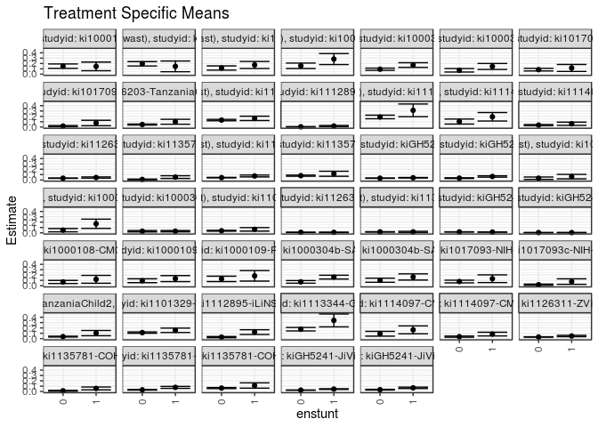

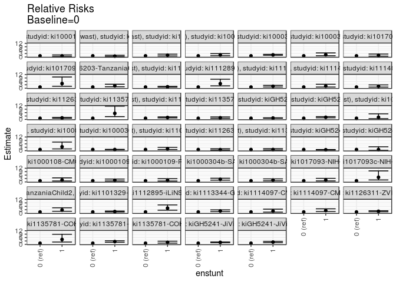

[figure not shown]

[figure not shown]

## Results Table

### Parameter: TSM

| agecat | studyid | country | intervention_level | baseline_level | estimate | ci_lower | ci_upper |
| --- | --- | --- | --- | --- | --- | --- | --- |
| 0-24 months (no birth wast) | ki1000108-CMC-V-BCS-2002 | INDIA | 0 | NA | 0.1497478 | 0.1087444 | 0.1907512 |
| 0-24 months (no birth wast) | ki1000108-CMC-V-BCS-2002 | INDIA | 1 | NA | 0.1454804 | 0.0648702 | 0.2260906 |
| 0-24 months (no birth wast) | ki1000108-IRC | INDIA | 0 | NA | 0.1939058 | 0.1530725 | 0.2347391 |
| 0-24 months (no birth wast) | ki1000108-IRC | INDIA | 1 | NA | 0.1458333 | 0.0458659 | 0.2458008 |
| 0-24 months (no birth wast) | ki1000109-EE | PAKISTAN | 0 | NA | 0.1153938 | 0.0756426 | 0.1551450 |
| 0-24 months (no birth wast) | ki1000109-EE | PAKISTAN | 1 | NA | 0.1724520 | 0.1070729 | 0.2378311 |
| 0-24 months (no birth wast) | ki1000109-ResPak | PAKISTAN | 0 | NA | 0.1568946 | 0.1062530 | 0.2075361 |
| 0-24 months (no birth wast) | ki1000109-ResPak | PAKISTAN | 1 | NA | 0.2823356 | 0.1798312 | 0.3848401 |
| 0-24 months (no birth wast) | ki1000304b-SAS-CompFeed | INDIA | 0 | NA | 0.0927861 | 0.0720711 | 0.1135011 |
| 0-24 months (no birth wast) | ki1000304b-SAS-CompFeed | INDIA | 1 | NA | 0.1705434 | 0.1269209 | 0.2141659 |
| 0-24 months (no birth wast) | ki1000304b-SAS-FoodSuppl | INDIA | 0 | NA | 0.0731289 | 0.0402137 | 0.1060440 |
| 0-24 months (no birth wast) | ki1000304b-SAS-FoodSuppl | INDIA | 1 | NA | 0.1439317 | 0.0880096 | 0.1998538 |
| 0-24 months (no birth wast) | ki1017093-NIH-Birth | BANGLADESH | 0 | NA | 0.0846380 | 0.0604073 | 0.1088686 |
| 0-24 months (no birth wast) | ki1017093-NIH-Birth | BANGLADESH | 1 | NA | 0.1163773 | 0.0512336 | 0.1815210 |
| 0-24 months (no birth wast) | ki1017093c-NIH-Crypto | BANGLADESH | 0 | NA | 0.0184900 | 0.0081188 | 0.0288612 |
| 0-24 months (no birth wast) | ki1017093c-NIH-Crypto | BANGLADESH | 1 | NA | 0.0761905 | 0.0254116 | 0.1269694 |
| 0-24 months (no birth wast) | ki1066203-TanzaniaChild2 | TANZANIA, UNITED REPUBLIC OF | 0 | NA | 0.0472611 | 0.0384355 | 0.0560867 |
| 0-24 months (no birth wast) | ki1066203-TanzaniaChild2 | TANZANIA, UNITED REPUBLIC OF | 1 | NA | 0.0994780 | 0.0532001 | 0.1457559 |
| 0-24 months (no birth wast) | ki1101329-Keneba | GAMBIA | 0 | NA | 0.1308455 | 0.1177495 | 0.1439415 |
| 0-24 months (no birth wast) | ki1101329-Keneba | GAMBIA | 1 | NA | 0.1629734 | 0.1224665 | 0.2034803 |
| 0-24 months (no birth wast) | ki1112895-iLiNS-Zinc | BURKINA FASO | 0 | NA | 0.0049069 | 0.0014662 | 0.0083477 |
| 0-24 months (no birth wast) | ki1112895-iLiNS-Zinc | BURKINA FASO | 1 | NA | 0.0196822 | 0.0095324 | 0.0298320 |
| 0-24 months (no birth wast) | ki1113344-GMS-Nepal | NEPAL | 0 | NA | 0.1886842 | 0.1550070 | 0.2223615 |
| 0-24 months (no birth wast) | ki1113344-GMS-Nepal | NEPAL | 1 | NA | 0.3127740 | 0.1944100 | 0.4311380 |
| 0-24 months (no birth wast) | ki1114097-CMIN | BANGLADESH | 0 | NA | 0.1028301 | 0.0560802 | 0.1495799 |
| 0-24 months (no birth wast) | ki1114097-CMIN | BANGLADESH | 1 | NA | 0.1923325 | 0.1130984 | 0.2715665 |
| 0-24 months (no birth wast) | ki1114097-CMIN | GUINEA-BISSAU | 0 | NA | 0.0371200 | 0.0265973 | 0.0476426 |
| 0-24 months (no birth wast) | ki1114097-CMIN | GUINEA-BISSAU | 1 | NA | 0.0618886 | 0.0322741 | 0.0915030 |
| 0-24 months (no birth wast) | ki1126311-ZVITAMBO | ZIMBABWE | 0 | NA | 0.0331489 | 0.0299743 | 0.0363235 |
| 0-24 months (no birth wast) | ki1126311-ZVITAMBO | ZIMBABWE | 1 | NA | 0.0452384 | 0.0341408 | 0.0563360 |

[output cut: 64 more lines]

### Parameter: E(Y)

| agecat | studyid | country | intervention_level | baseline_level | estimate | ci_lower | ci_upper |
| --- | --- | --- | --- | --- | --- | --- | --- |
| 0-24 months (no birth wast) | ki1000108-CMC-V-BCS-2002 | INDIA | NA | NA | 0.1494565 | 0.1129794 | 0.1859337 |
| 0-24 months (no birth wast) | ki1000108-IRC | INDIA | NA | NA | 0.1882641 | 0.1503318 | 0.2261964 |
| 0-24 months (no birth wast) | ki1000109-EE | PAKISTAN | NA | NA | 0.1352785 | 0.1007079 | 0.1698491 |
| 0-24 months (no birth wast) | ki1000109-ResPak | PAKISTAN | NA | NA | 0.1897810 | 0.1432659 | 0.2362962 |
| 0-24 months (no birth wast) | ki1000304b-SAS-CompFeed | INDIA | NA | NA | 0.1145140 | 0.0913579 | 0.1376700 |
| 0-24 months (no birth wast) | ki1000304b-SAS-FoodSuppl | INDIA | NA | NA | 0.1007557 | 0.0711091 | 0.1304022 |
| 0-24 months (no birth wast) | ki1017093-NIH-Birth | BANGLADESH | NA | NA | 0.0897010 | 0.0668555 | 0.1125465 |
| 0-24 months (no birth wast) | ki1017093c-NIH-Crypto | BANGLADESH | NA | NA | 0.0265252 | 0.0150478 | 0.0380026 |
| 0-24 months (no birth wast) | ki1066203-TanzaniaChild2 | TANZANIA, UNITED REPUBLIC OF | NA | NA | 0.0507550 | 0.0419422 | 0.0595679 |
| 0-24 months (no birth wast) | ki1101329-Keneba | GAMBIA | NA | NA | 0.1342867 | 0.1218039 | 0.1467696 |
| 0-24 months (no birth wast) | ki1112895-iLiNS-Zinc | BURKINA FASO | NA | NA | 0.0080880 | 0.0040249 | 0.0121511 |
| 0-24 months (no birth wast) | ki1113344-GMS-Nepal | NEPAL | NA | NA | 0.1983051 | 0.1661046 | 0.2305055 |
| 0-24 months (no birth wast) | ki1114097-CMIN | BANGLADESH | NA | NA | 0.1380597 | 0.0966822 | 0.1794372 |
| 0-24 months (no birth wast) | ki1114097-CMIN | GUINEA-BISSAU | NA | NA | 0.0413333 | 0.0312563 | 0.0514103 |
| 0-24 months (no birth wast) | ki1126311-ZVITAMBO | ZIMBABWE | NA | NA | 0.0344245 | 0.0313630 | 0.0374861 |
| 0-24 months (no birth wast) | ki1135781-COHORTS | GUATEMALA | NA | NA | 0.0202703 | 0.0126995 | 0.0278411 |
| 0-24 months (no birth wast) | ki1135781-COHORTS | INDIA | NA | NA | 0.0472320 | 0.0423094 | 0.0521545 |
| 0-24 months (no birth wast) | ki1135781-COHORTS | PHILIPPINES | NA | NA | 0.0824776 | 0.0726632 | 0.0922921 |
| 0-24 months (no birth wast) | kiGH5241-JiVitA-3 | BANGLADESH | NA | NA | 0.0356914 | 0.0331158 | 0.0382671 |
| 0-24 months (no birth wast) | kiGH5241-JiVitA-4 | BANGLADESH | NA | NA | 0.0429948 | 0.0372768 | 0.0487128 |
| 0-6 months (no birth wast) | ki1000109-EE | PAKISTAN | NA | NA | 0.0428954 | 0.0223052 | 0.0634857 |
| 0-6 months (no birth wast) | ki1000109-ResPak | PAKISTAN | NA | NA | 0.0808824 | 0.0484203 | 0.1133444 |
| 0-6 months (no birth wast) | ki1000304b-SAS-CompFeed | INDIA | NA | NA | 0.0312288 | 0.0186884 | 0.0437692 |
| 0-6 months (no birth wast) | ki1101329-Keneba | GAMBIA | NA | NA | 0.0410788 | 0.0331533 | 0.0490044 |
| 0-6 months (no birth wast) | ki1126311-ZVITAMBO | ZIMBABWE | NA | NA | 0.0098032 | 0.0081326 | 0.0114737 |
| 0-6 months (no birth wast) | ki1135781-COHORTS | INDIA | NA | NA | 0.0179724 | 0.0147449 | 0.0211998 |
| 0-6 months (no birth wast) | kiGH5241-JiVitA-3 | BANGLADESH | NA | NA | 0.0165409 | 0.0147291 | 0.0183527 |
| 0-6 months (no birth wast) | kiGH5241-JiVitA-4 | BANGLADESH | NA | NA | 0.0042364 | 0.0017272 | 0.0067456 |
| 6-24 months | ki1000108-CMC-V-BCS-2002 | INDIA | NA | NA | 0.0804290 | 0.0527929 | 0.1080650 |
| 6-24 months | ki1000109-EE | PAKISTAN | NA | NA | 0.1040000 | 0.0730627 | 0.1349373 |
| 6-24 months | ki1000109-ResPak | PAKISTAN | NA | NA | 0.1434783 | 0.0980744 | 0.1888821 |
| 6-24 months | ki1000304b-SAS-CompFeed | INDIA | NA | NA | 0.0964723 | 0.0729872 | 0.1199573 |
| 6-24 months | ki1000304b-SAS-FoodSuppl | INDIA | NA | NA | 0.1268657 | 0.0942904 | 0.1594410 |
| 6-24 months | ki1017093-NIH-Birth | BANGLADESH | NA | NA | 0.0868762 | 0.0631205 | 0.1106318 |
| 6-24 months | ki1017093c-NIH-Crypto | BANGLADESH | NA | NA | 0.0273973 | 0.0155476 | 0.0392469 |
| 6-24 months | ki1066203-TanzaniaChild2 | TANZANIA, UNITED REPUBLIC OF | NA | NA | 0.0411298 | 0.0324631 | 0.0497965 |
| 6-24 months | ki1101329-Keneba | GAMBIA | NA | NA | 0.1172389 | 0.1051866 | 0.1292911 |
| 6-24 months | ki1112895-iLiNS-Zinc | BURKINA FASO | NA | NA | 0.0505205 | 0.0383088 | 0.0627322 |
| 6-24 months | ki1113344-GMS-Nepal | NEPAL | NA | NA | 0.1915254 | 0.1597467 | 0.2233042 |
| 6-24 months | ki1114097-CMIN | BANGLADESH | NA | NA | 0.1150794 | 0.0756007 | 0.1545580 |
| 6-24 months | ki1114097-CMIN | GUINEA-BISSAU | NA | NA | 0.0452092 | 0.0346279 | 0.0557905 |
| 6-24 months | ki1126311-ZVITAMBO | ZIMBABWE | NA | NA | 0.0325416 | 0.0291786 | 0.0359047 |
| 6-24 months | ki1135781-COHORTS | GUATEMALA | NA | NA | 0.0245902 | 0.0158961 | 0.0332842 |
| 6-24 months | ki1135781-COHORTS | INDIA | NA | NA | 0.0368823 | 0.0324481 | 0.0413165 |
| 6-24 months | ki1135781-COHORTS | PHILIPPINES | NA | NA | 0.0669277 | 0.0576848 | 0.0761707 |
| 6-24 months | kiGH5241-JiVitA-3 | BANGLADESH | NA | NA | 0.0319690 | 0.0290813 | 0.0348568 |
| 6-24 months | kiGH5241-JiVitA-4 | BANGLADESH | NA | NA | 0.0440147 | 0.0381801 | 0.0498493 |

### Parameter: RR

| agecat | studyid | country | intervention_level | baseline_level | estimate | ci_lower | ci_upper |
| --- | --- | --- | --- | --- | --- | --- | --- |
| 0-24 months (no birth wast) | ki1000108-CMC-V-BCS-2002 | INDIA | 0 | 0 | 1.0000000 | 1.0000000 | 1.000000 |
| 0-24 months (no birth wast) | ki1000108-CMC-V-BCS-2002 | INDIA | 1 | 0 | 0.9715028 | 0.5229758 | 1.804706 |
| 0-24 months (no birth wast) | ki1000108-IRC | INDIA | 0 | 0 | 1.0000000 | 1.0000000 | 1.000000 |
| 0-24 months (no birth wast) | ki1000108-IRC | INDIA | 1 | 0 | 0.7520833 | 0.3671386 | 1.540643 |
| 0-24 months (no birth wast) | ki1000109-EE | PAKISTAN | 0 | 0 | 1.0000000 | 1.0000000 | 1.000000 |
| 0-24 months (no birth wast) | ki1000109-EE | PAKISTAN | 1 | 0 | 1.4944653 | 0.8960174 | 2.492615 |
| 0-24 months (no birth wast) | ki1000109-ResPak | PAKISTAN | 0 | 0 | 1.0000000 | 1.0000000 | 1.000000 |
| 0-24 months (no birth wast) | ki1000109-ResPak | PAKISTAN | 1 | 0 | 1.7995247 | 1.1108346 | 2.915186 |
| 0-24 months (no birth wast) | ki1000304b-SAS-CompFeed | INDIA | 0 | 0 | 1.0000000 | 1.0000000 | 1.000000 |
| 0-24 months (no birth wast) | ki1000304b-SAS-CompFeed | INDIA | 1 | 0 | 1.8380274 | 1.4708345 | 2.296890 |
| 0-24 months (no birth wast) | ki1000304b-SAS-FoodSuppl | INDIA | 0 | 0 | 1.0000000 | 1.0000000 | 1.000000 |
| 0-24 months (no birth wast) | ki1000304b-SAS-FoodSuppl | INDIA | 1 | 0 | 1.9681930 | 1.0863369 | 3.565914 |
| 0-24 months (no birth wast) | ki1017093-NIH-Birth | BANGLADESH | 0 | 0 | 1.0000000 | 1.0000000 | 1.000000 |
| 0-24 months (no birth wast) | ki1017093-NIH-Birth | BANGLADESH | 1 | 0 | 1.3750013 | 0.7335427 | 2.577394 |
| 0-24 months (no birth wast) | ki1017093c-NIH-Crypto | BANGLADESH | 0 | 0 | 1.0000000 | 1.0000000 | 1.000000 |
| 0-24 months (no birth wast) | ki1017093c-NIH-Crypto | BANGLADESH | 1 | 0 | 4.1206348 | 1.7244576 | 9.846361 |
| 0-24 months (no birth wast) | ki1066203-TanzaniaChild2 | TANZANIA, UNITED REPUBLIC OF | 0 | 0 | 1.0000000 | 1.0000000 | 1.000000 |
| 0-24 months (no birth wast) | ki1066203-TanzaniaChild2 | TANZANIA, UNITED REPUBLIC OF | 1 | 0 | 2.1048608 | 1.2749891 | 3.474884 |
| 0-24 months (no birth wast) | ki1101329-Keneba | GAMBIA | 0 | 0 | 1.0000000 | 1.0000000 | 1.000000 |
| 0-24 months (no birth wast) | ki1101329-Keneba | GAMBIA | 1 | 0 | 1.2455408 | 0.9533538 | 1.627278 |
| 0-24 months (no birth wast) | ki1112895-iLiNS-Zinc | BURKINA FASO | 0 | 0 | 1.0000000 | 1.0000000 | 1.000000 |
| 0-24 months (no birth wast) | ki1112895-iLiNS-Zinc | BURKINA FASO | 1 | 0 | 4.0111082 | 2.0360560 | 7.902037 |
| 0-24 months (no birth wast) | ki1113344-GMS-Nepal | NEPAL | 0 | 0 | 1.0000000 | 1.0000000 | 1.000000 |
| 0-24 months (no birth wast) | ki1113344-GMS-Nepal | NEPAL | 1 | 0 | 1.6576583 | 1.0909170 | 2.518827 |
| 0-24 months (no birth wast) | ki1114097-CMIN | BANGLADESH | 0 | 0 | 1.0000000 | 1.0000000 | 1.000000 |
| 0-24 months (no birth wast) | ki1114097-CMIN | BANGLADESH | 1 | 0 | 1.8703918 | 1.0110863 | 3.460007 |
| 0-24 months (no birth wast) | ki1114097-CMIN | GUINEA-BISSAU | 0 | 0 | 1.0000000 | 1.0000000 | 1.000000 |
| 0-24 months (no birth wast) | ki1114097-CMIN | GUINEA-BISSAU | 1 | 0 | 1.6672574 | 0.9559790 | 2.907749 |
| 0-24 months (no birth wast) | ki1126311-ZVITAMBO | ZIMBABWE | 0 | 0 | 1.0000000 | 1.0000000 | 1.000000 |
| 0-24 months (no birth wast) | ki1126311-ZVITAMBO | ZIMBABWE | 1 | 0 | 1.3647027 | 1.0487852 | 1.775782 |

[output cut: 64 more lines]

### Parameter: PAR

| agecat | studyid | country | intervention_level | baseline_level | estimate | ci_lower | ci_upper |
| --- | --- | --- | --- | --- | --- | --- | --- |
| 0-24 months (no birth wast) | ki1000108-CMC-V-BCS-2002 | INDIA | 0 | NA | -0.0002913 | -0.0188369 | 0.0182543 |
| 0-24 months (no birth wast) | ki1000108-IRC | INDIA | 0 | NA | -0.0056418 | -0.0184035 | 0.0071200 |
| 0-24 months (no birth wast) | ki1000109-EE | PAKISTAN | 0 | NA | 0.0198847 | -0.0066265 | 0.0463960 |
| 0-24 months (no birth wast) | ki1000109-ResPak | PAKISTAN | 0 | NA | 0.0328865 | 0.0021569 | 0.0636161 |
| 0-24 months (no birth wast) | ki1000304b-SAS-CompFeed | INDIA | 0 | NA | 0.0217279 | 0.0128981 | 0.0305577 |
| 0-24 months (no birth wast) | ki1000304b-SAS-FoodSuppl | INDIA | 0 | NA | 0.0276268 | 0.0024979 | 0.0527557 |
| 0-24 months (no birth wast) | ki1017093-NIH-Birth | BANGLADESH | 0 | NA | 0.0050630 | -0.0058318 | 0.0159579 |
| 0-24 months (no birth wast) | ki1017093c-NIH-Crypto | BANGLADESH | 0 | NA | 0.0080352 | 0.0006782 | 0.0153922 |
| 0-24 months (no birth wast) | ki1066203-TanzaniaChild2 | TANZANIA, UNITED REPUBLIC OF | 0 | NA | 0.0034940 | 0.0002705 | 0.0067174 |
| 0-24 months (no birth wast) | ki1101329-Keneba | GAMBIA | 0 | NA | 0.0034412 | -0.0011996 | 0.0080820 |
| 0-24 months (no birth wast) | ki1112895-iLiNS-Zinc | BURKINA FASO | 0 | NA | 0.0031811 | 0.0013458 | 0.0050163 |
| 0-24 months (no birth wast) | ki1113344-GMS-Nepal | NEPAL | 0 | NA | 0.0096208 | -0.0033666 | 0.0226083 |
| 0-24 months (no birth wast) | ki1114097-CMIN | BANGLADESH | 0 | NA | 0.0352296 | 0.0001604 | 0.0702989 |
| 0-24 months (no birth wast) | ki1114097-CMIN | GUINEA-BISSAU | 0 | NA | 0.0042134 | -0.0011920 | 0.0096187 |
| 0-24 months (no birth wast) | ki1126311-ZVITAMBO | ZIMBABWE | 0 | NA | 0.0012757 | 0.0001028 | 0.0024485 |
| 0-24 months (no birth wast) | ki1135781-COHORTS | GUATEMALA | 0 | NA | 0.0103399 | 0.0041657 | 0.0165141 |
| 0-24 months (no birth wast) | ki1135781-COHORTS | INDIA | 0 | NA | 0.0036653 | 0.0014668 | 0.0058637 |
| 0-24 months (no birth wast) | ki1135781-COHORTS | PHILIPPINES | 0 | NA | 0.0023724 | -0.0005007 | 0.0052454 |
| 0-24 months (no birth wast) | kiGH5241-JiVitA-3 | BANGLADESH | 0 | NA | 0.0025207 | 0.0007789 | 0.0042626 |
| 0-24 months (no birth wast) | kiGH5241-JiVitA-4 | BANGLADESH | 0 | NA | 0.0086756 | 0.0046236 | 0.0127276 |
| 0-6 months (no birth wast) | ki1000109-EE | PAKISTAN | 0 | NA | 0.0101086 | -0.0063115 | 0.0265286 |
| 0-6 months (no birth wast) | ki1000109-ResPak | PAKISTAN | 0 | NA | 0.0312550 | 0.0063430 | 0.0561670 |
| 0-6 months (no birth wast) | ki1000304b-SAS-CompFeed | INDIA | 0 | NA | 0.0002448 | -0.0016692 | 0.0021589 |
| 0-6 months (no birth wast) | ki1101329-Keneba | GAMBIA | 0 | NA | 0.0025587 | -0.0006079 | 0.0057253 |
| 0-6 months (no birth wast) | ki1126311-ZVITAMBO | ZIMBABWE | 0 | NA | -0.0001545 | -0.0006701 | 0.0003611 |
| 0-6 months (no birth wast) | ki1135781-COHORTS | INDIA | 0 | NA | 0.0000560 | -0.0010839 | 0.0011958 |
| 0-6 months (no birth wast) | kiGH5241-JiVitA-3 | BANGLADESH | 0 | NA | -0.0009955 | -0.0021021 | 0.0001112 |
| 0-6 months (no birth wast) | kiGH5241-JiVitA-4 | BANGLADESH | 0 | NA | 0.0000300 | -0.0014141 | 0.0014742 |
| 6-24 months | ki1000108-CMC-V-BCS-2002 | INDIA | 0 | NA | 0.0099592 | -0.0060897 | 0.0260080 |
| 6-24 months | ki1000109-EE | PAKISTAN | 0 | NA | 0.0104478 | -0.0130310 | 0.0339266 |
| 6-24 months | ki1000109-ResPak | PAKISTAN | 0 | NA | 0.0154581 | -0.0134045 | 0.0443207 |
| 6-24 months | ki1000304b-SAS-CompFeed | INDIA | 0 | NA | 0.0245427 | 0.0136032 | 0.0354822 |
| 6-24 months | ki1000304b-SAS-FoodSuppl | INDIA | 0 | NA | 0.0238261 | -0.0036021 | 0.0512543 |
| 6-24 months | ki1017093-NIH-Birth | BANGLADESH | 0 | NA | 0.0081411 | -0.0038944 | 0.0201767 |
| 6-24 months | ki1017093c-NIH-Crypto | BANGLADESH | 0 | NA | 0.0082585 | 0.0006596 | 0.0158574 |
| 6-24 months | ki1066203-TanzaniaChild2 | TANZANIA, UNITED REPUBLIC OF | 0 | NA | 0.0039235 | 0.0004791 | 0.0073680 |
| 6-24 months | ki1101329-Keneba | GAMBIA | 0 | NA | 0.0045766 | -0.0001572 | 0.0093104 |
| 6-24 months | ki1112895-iLiNS-Zinc | BURKINA FASO | 0 | NA | 0.0225026 | 0.0137173 | 0.0312879 |
| 6-24 months | ki1113344-GMS-Nepal | NEPAL | 0 | NA | 0.0156159 | 0.0023297 | 0.0289021 |
| 6-24 months | ki1114097-CMIN | BANGLADESH | 0 | NA | 0.0239264 | -0.0090900 | 0.0569428 |
| 6-24 months | ki1114097-CMIN | GUINEA-BISSAU | 0 | NA | 0.0084129 | 0.0021251 | 0.0147008 |
| 6-24 months | ki1126311-ZVITAMBO | ZIMBABWE | 0 | NA | 0.0019678 | 0.0005784 | 0.0033572 |
| 6-24 months | ki1135781-COHORTS | GUATEMALA | 0 | NA | 0.0112122 | 0.0042022 | 0.0182221 |
| 6-24 months | ki1135781-COHORTS | INDIA | 0 | NA | 0.0054274 | 0.0031668 | 0.0076881 |
| 6-24 months | ki1135781-COHORTS | PHILIPPINES | 0 | NA | 0.0027558 | -0.0001234 | 0.0056349 |
| 6-24 months | kiGH5241-JiVitA-3 | BANGLADESH | 0 | NA | 0.0060547 | 0.0039127 | 0.0081968 |
| 6-24 months | kiGH5241-JiVitA-4 | BANGLADESH | 0 | NA | 0.0098548 | 0.0055326 | 0.0141769 |

### Parameter: PAF

| agecat | studyid | country | intervention_level | baseline_level | estimate | ci_lower | ci_upper |
| --- | --- | --- | --- | --- | --- | --- | --- |
| 0-24 months (no birth wast) | ki1000108-CMC-V-BCS-2002 | INDIA | 0 | NA | -0.0019490 | -0.1340455 | 0.1147606 |
| 0-24 months (no birth wast) | ki1000108-IRC | INDIA | 0 | NA | -0.0299673 | -0.0998838 | 0.0355049 |
| 0-24 months (no birth wast) | ki1000109-EE | PAKISTAN | 0 | NA | 0.1469912 | -0.0696377 | 0.3197472 |
| 0-24 months (no birth wast) | ki1000109-ResPak | PAKISTAN | 0 | NA | 0.1732863 | -0.0025165 | 0.3182602 |
| 0-24 months (no birth wast) | ki1000304b-SAS-CompFeed | INDIA | 0 | NA | 0.1897401 | 0.1178836 | 0.2557432 |
| 0-24 months (no birth wast) | ki1000304b-SAS-FoodSuppl | INDIA | 0 | NA | 0.2741961 | -0.0090233 | 0.4779197 |
| 0-24 months (no birth wast) | ki1017093-NIH-Birth | BANGLADESH | 0 | NA | 0.0564435 | -0.0723864 | 0.1697965 |
| 0-24 months (no birth wast) | ki1017093c-NIH-Crypto | BANGLADESH | 0 | NA | 0.3029276 | 0.0082660 | 0.5100400 |
| 0-24 months (no birth wast) | ki1066203-TanzaniaChild2 | TANZANIA, UNITED REPUBLIC OF | 0 | NA | 0.0688395 | 0.0042079 | 0.1292763 |
| 0-24 months (no birth wast) | ki1101329-Keneba | GAMBIA | 0 | NA | 0.0256259 | -0.0095134 | 0.0595422 |
| 0-24 months (no birth wast) | ki1112895-iLiNS-Zinc | BURKINA FASO | 0 | NA | 0.3933080 | 0.1488291 | 0.5675661 |
| 0-24 months (no birth wast) | ki1113344-GMS-Nepal | NEPAL | 0 | NA | 0.0485154 | -0.0190706 | 0.1116190 |
| 0-24 months (no birth wast) | ki1114097-CMIN | BANGLADESH | 0 | NA | 0.2551769 | -0.0355510 | 0.4642838 |
| 0-24 months (no birth wast) | ki1114097-CMIN | GUINEA-BISSAU | 0 | NA | 0.1019361 | -0.0362657 | 0.2217066 |
| 0-24 months (no birth wast) | ki1126311-ZVITAMBO | ZIMBABWE | 0 | NA | 0.0370566 | 0.0025299 | 0.0703883 |
| 0-24 months (no birth wast) | ki1135781-COHORTS | GUATEMALA | 0 | NA | 0.5100996 | 0.2022733 | 0.6991420 |
| 0-24 months (no birth wast) | ki1135781-COHORTS | INDIA | 0 | NA | 0.0776011 | 0.0305406 | 0.1223771 |
| 0-24 months (no birth wast) | ki1135781-COHORTS | PHILIPPINES | 0 | NA | 0.0287637 | -0.0065672 | 0.0628544 |
| 0-24 months (no birth wast) | kiGH5241-JiVitA-3 | BANGLADESH | 0 | NA | 0.0706260 | 0.0207726 | 0.1179413 |
| 0-24 months (no birth wast) | kiGH5241-JiVitA-4 | BANGLADESH | 0 | NA | 0.2017821 | 0.1013334 | 0.2910032 |
| 0-6 months (no birth wast) | ki1000109-EE | PAKISTAN | 0 | NA | 0.2356557 | -0.2352502 | 0.5270414 |
| 0-6 months (no birth wast) | ki1000109-ResPak | PAKISTAN | 0 | NA | 0.3864258 | 0.0419667 | 0.6070353 |
| 0-6 months (no birth wast) | ki1000304b-SAS-CompFeed | INDIA | 0 | NA | 0.0078402 | -0.0559026 | 0.0677349 |
| 0-6 months (no birth wast) | ki1101329-Keneba | GAMBIA | 0 | NA | 0.0622872 | -0.0171595 | 0.1355286 |
| 0-6 months (no birth wast) | ki1126311-ZVITAMBO | ZIMBABWE | 0 | NA | -0.0157603 | -0.0696641 | 0.0354271 |
| 0-6 months (no birth wast) | ki1135781-COHORTS | INDIA | 0 | NA | 0.0031140 | -0.0623687 | 0.0645604 |
| 0-6 months (no birth wast) | kiGH5241-JiVitA-3 | BANGLADESH | 0 | NA | -0.0601828 | -0.1288608 | 0.0043170 |
| 0-6 months (no birth wast) | kiGH5241-JiVitA-4 | BANGLADESH | 0 | NA | 0.0070908 | -0.4007295 | 0.2961748 |
| 6-24 months | ki1000108-CMC-V-BCS-2002 | INDIA | 0 | NA | 0.1238255 | -0.0954049 | 0.2991799 |
| 6-24 months | ki1000109-EE | PAKISTAN | 0 | NA | 0.1004599 | -0.1533434 | 0.2984116 |
| 6-24 months | ki1000109-ResPak | PAKISTAN | 0 | NA | 0.1077384 | -0.1157289 | 0.2864478 |
| 6-24 months | ki1000304b-SAS-CompFeed | INDIA | 0 | NA | 0.2544016 | 0.1175155 | 0.3700546 |
| 6-24 months | ki1000304b-SAS-FoodSuppl | INDIA | 0 | NA | 0.1878058 | -0.0544660 | 0.3744137 |
| 6-24 months | ki1017093-NIH-Birth | BANGLADESH | 0 | NA | 0.0937097 | -0.0537848 | 0.2205599 |
| 6-24 months | ki1017093c-NIH-Crypto | BANGLADESH | 0 | NA | 0.3014354 | 0.0063132 | 0.5089071 |
| 6-24 months | ki1066203-TanzaniaChild2 | TANZANIA, UNITED REPUBLIC OF | 0 | NA | 0.0953940 | 0.0101055 | 0.1733341 |
| 6-24 months | ki1101329-Keneba | GAMBIA | 0 | NA | 0.0390366 | -0.0020544 | 0.0784427 |
| 6-24 months | ki1112895-iLiNS-Zinc | BURKINA FASO | 0 | NA | 0.4454150 | 0.2726337 | 0.5771531 |
| 6-24 months | ki1113344-GMS-Nepal | NEPAL | 0 | NA | 0.0815343 | 0.0101134 | 0.1478021 |
| 6-24 months | ki1114097-CMIN | BANGLADESH | 0 | NA | 0.2079122 | -0.1256173 | 0.4426141 |
| 6-24 months | ki1114097-CMIN | GUINEA-BISSAU | 0 | NA | 0.1860891 | 0.0420468 | 0.3084725 |
| 6-24 months | ki1126311-ZVITAMBO | ZIMBABWE | 0 | NA | 0.0604713 | 0.0172500 | 0.1017916 |
| 6-24 months | ki1135781-COHORTS | GUATEMALA | 0 | NA | 0.4559622 | 0.1597039 | 0.6477705 |
| 6-24 months | ki1135781-COHORTS | INDIA | 0 | NA | 0.1471558 | 0.0861885 | 0.2040555 |
| 6-24 months | ki1135781-COHORTS | PHILIPPINES | 0 | NA | 0.0411752 | -0.0024923 | 0.0829407 |
| 6-24 months | kiGH5241-JiVitA-3 | BANGLADESH | 0 | NA | 0.1893941 | 0.1229530 | 0.2508019 |
| 6-24 months | kiGH5241-JiVitA-4 | BANGLADESH | 0 | NA | 0.2238967 | 0.1210386 | 0.3147181 |